# Jacobian Question

Bret Larget

11/7/2016

### Example Question

Suppose that we have a parameter vector $\theta = (\theta_1,\ldots,\theta_k) \in \mathbb{R}^k$ and $\theta \sim F$ for some distribution $F$. We also have a function $h: \mathbb{R}^k \rightarrow \Delta^m$ where $\Delta^m = \{(t_1,\ldots,t_m) \in \mathbb{R}^m: \sum_i t_i = 1 \ \text{and} \ t_i > 0 \ \text{for all} \ i\}$ is the $m$ dimensional simplex. Let $\phi = (\phi_1,\ldots,\phi_m) = h(\theta)$. Then, suppose that we have an iid multinomial sample $X = (X_1,\ldots,X_n)$ with $X_i \sim \text{Multinomial}(\phi)$ for $i=1,\ldots,n$.

The Bayesian posterior density $p(\theta \mid X)$ is our target density. We want to estimate this density using importance sampling. We generate $B$ realizations $\theta^* \sim G$ with $\theta^* \in \mathbb{R}^k$. How do we calculate the correct importance weights?

### Specific Example 1

Let $\theta \sim \text{Dirichlet}(1,1,1)$. Define $\eta_1 = \theta_1$, $\eta_2 = \theta_2$, $\eta_3 = \theta_3$, and $\eta_4 = \theta_1\theta_2\theta_3$. Define $\phi_i = \eta_i / \sum_j \eta_j$. If $X \sim \text{Multinomial}(\phi)$, the $X$ has possible values $1,\ldots,4$ with probabilities $\phi$.

Here is code to generate random data.

```r
rx1 = function(n)
{
  theta = rgamma(3,1)
  theta = theta / sum(theta)
  eta = c(theta,prod(theta))
  phi = eta/sum(eta)
  x = sample(1:4,size=n,replace=TRUE,prob=phi)
  return(list(x=x,theta=theta))
}
set.seed(25463)
out1 = rx1(100)
x1 = out1$x
theta1 = out1$theta
tab1 = table(x1)
tab1
```

```
## x1
##  1  2  3  4
## 20 45 31  4
```

```r
theta1
```

```
## [1] 0.1756056 0.5474398 0.2769546
```

MLE estimation

```r
mle = function(x)
{
  tab1 = tabulate(x,4)
  foo1 = tab1[1] + tab1[4]
  foo2 = tab1[2] + tab1[4]
  foo3 = tab1[3] + tab1[4]
  mle1 = c(foo1*foo3,foo2*foo3)/((foo1+foo3)*(foo2+foo3)-(foo1*foo2))
  return(mle1)
}
mle1 = mle(x1)
theta1.hat = c(mle1,1-sum(mle1))
theta1.hat
```

```
## [1] 0.2222222 0.4537037 0.3240741
```

Do MCMC.

```r
## Assumes flat prior for theta
log.post = function(theta,tab)
{
  eta = c(theta,prod(theta))
  phi = eta/sum(eta)
  return ( sum(tab*log(phi)) )
}
## random dirichlet with alpha[i] = eta*x[i] + 1
rdirichlet = function(alpha)
{
##  alpha = eta*x+1
  n = length(alpha)
  y = rgamma(n,alpha,1)
  return(y/sum(y))
}

ddirichlet = function(x,alpha,log=TRUE)
{
  k = lgamma(sum(alpha)) - sum(lgamma(alpha))
  y = sum( (alpha-1)*log(x) )
  if ( log )
    return( k + y )
  else
    return( exp(k + y) )
}

mcmc1 = function(x,B=10000,tune=1)
{
  tab = tabulate(x,4)
  theta = matrix(0,B,3)
  curr = mle(x)
  curr = c(curr,1-sum(curr))
  n = sum(tab)
  accept = rep(0,B)
  log.like = rep(0,B)
  for ( i in 1:B )
  {
    alpha = curr*n*tune + 1
    prop = rdirichlet(alpha)
    log.prob =
      log.post(prop,tab) -
      log.post(curr,tab) +
      ddirichlet(curr,prop*n*tune+1,log=TRUE) -
      ddirichlet(prop,alpha,log=TRUE)
    if ( log.prob > 0 )
      p = 1
    else
      p = exp(log.prob)
    log.like[i] = log.post(curr,tab)
    accept[i] = p
    if ( runif(1) < p )
    {
      curr = prop
    }
    theta[i,] = curr
  }
  df = data.frame(gen=1:B,log.like=log.like,theta1=theta[,1],theta2=theta[,2],theta3=theta[,3],accept=accept)
  return(df)
}
out1 = mcmc1(x=x1,B=11000)
```

Plot output

```r
require(viridis)
```

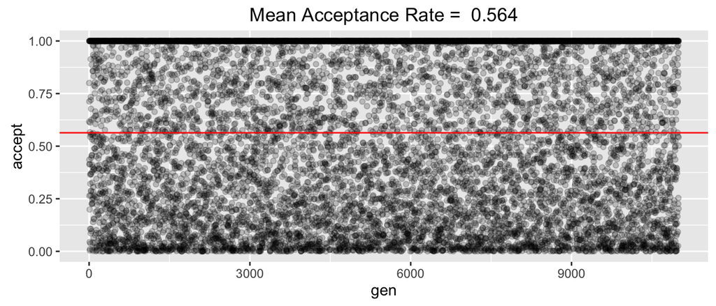

```r
df0 = out1
df = out1[1001:11000,]
ggplot(df0,aes(x=gen,y=accept)) +
  geom_point(alpha=0.2) +
  geom_hline(yintercept=mean(df0$accept),color="red") +
  ggtitle(paste("Mean Acceptance Rate = ",round(mean(df0$accept),3)))
```

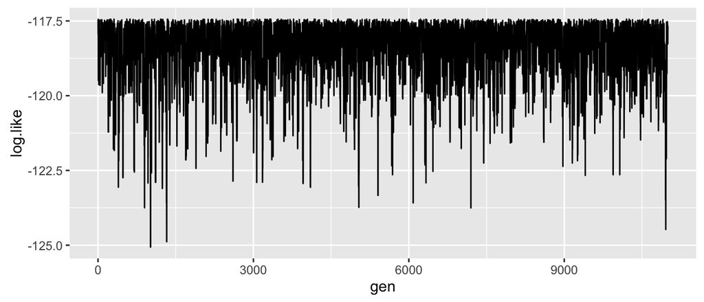

```r
ggplot(df0,aes(x=gen,y=log.like)) +
  geom_line()
```

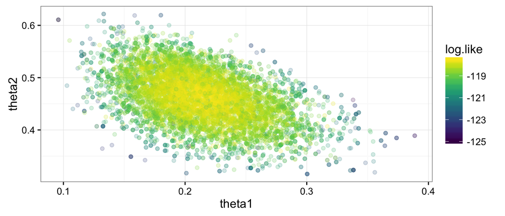

```r
ggplot(df,aes(x=theta1,y=theta2,color=log.like)) +
  geom_point(alpha=0.2) +
  scale_color_viridis() +
  theme_bw()
```

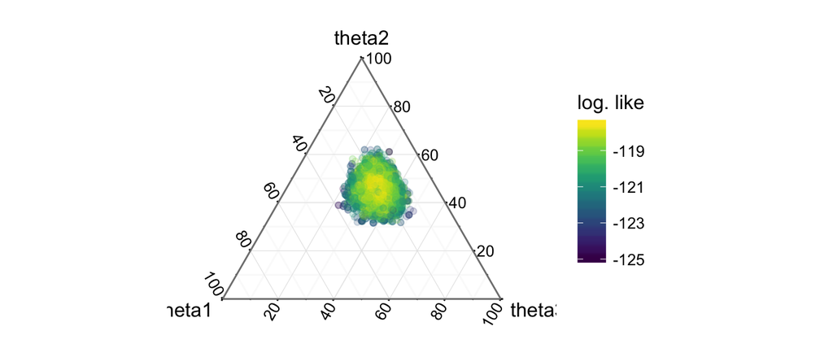

```r
ggtern(df,aes(theta1,theta2,theta3,color=log.like)) +
  geom_point(alpha=0.2) +
  scale_color_viridis() +
  theme_bw()
```

### Specific Example 2

Let $\theta_{i,j} \sim N(0,1)$ for $1 \le i < j \le 4$, so there are a total of six iid standard normal random variables. Define the symmetric $4 \times 4$ matrix $M = \{m_{i,j}\}$ by
$$m_{i,j} = \left\{
\begin{array}{ll}
\mathrm{e}^{\theta_{i,j}} & \text{if $i<j$} \\
\mathrm{e}^{\theta_{j,i}} & \text{if $j<i$} \\
0 & \text{if $i=j$}
\end{array}
\right.$$
Define $\mathbf{1} = (1,1,1,1)^\top$. Let $\phi = M\mathbf{1}\, /\, (\mathbf{1}^\top M \mathbf{1})$. Note that $\phi = (\phi_1,\ldots,\phi_4)$, where $\phi_j>0$ and $\sum_j \phi_j = 1$.

Here is code to generate $X$ from this model.

```r
rx = function(n)
{
  theta = rnorm(6)
  m = matrix(0,4,4)
  m[row(m) > col(m)] = exp(theta)
  m = m + t(m)
  phi = apply(m,1,sum)
  phi = phi / sum(phi)
  x = sample(1:4,size=n,replace=TRUE,prob=phi)
  return( list(x=x,theta=theta,phi=phi) )
}
```

##### Get a data set

```r
set.seed(35345)
out = rx(100)
x = out$x
theta = out$theta
rm(out)
table(x)
```

```
## x
##  1  2  3  4
## 42 40  5 13
```

```r
print(theta)
```

```
## [1]  1.5650641 -0.3462935  0.2249704 -0.5576324  0.1388554 -1.0717102
```